# Week 2

Judit Kisistók

2018-02-07

### A. Table of contents

1. Table of contents
2. Learning goals
3. Exercises
   - Calculating summary statistics in a sample
   - Summarizing and visualizing the Stickleback data of Chapter 3
   - Developing your intuition for histograms and boxplots
   - Making up your own data by sampling from a theoretical distribution

### Learning goals

#### By the end of this session, you should be able to…

- load datasets in R from the ABD package
- calculate summary statistics by hand and using the summary stats functions in R
- slice data in R (selecting subsets of data)
- create data but also sample data from a first theoretical distribution and discuss how much samples from this distribution are close to the real observed data
- be good at making the correspondance between summary statistics (mean, median, SD, etc.) and graphical representation of the data by:
  - histograms
  - boxplots
  - cumulative frequency distributions

### 1. Calculating summary statistics in a sample

Here is how you can “make” your own data sample (redo Exercise 3.1 in R)

```r
myDataNyHand=c(1.23,1.5,2,3,4,1,4) ## a new vector
# c stands for concatenation - so here you're essentially concatenating a bunch of numbers together into a vector
```

#### Create a vector containing the data in Example 3 3.1.

```r
data=c(0.9, 1.4, 1.2, 1.2, 1.3, 2.0, 1.4, 1.6)
```

#### Check with pencil and paper and with R that you can calculate all the summary statistics presented in the book example (mean, median, SD, quantiles), then check with the R function how to get these statistics directly.

```r
meanOfData = mean(data)
meanOfData
```

```
## [1] 1.375
```

```r
SDOfData = sd(data)
SDOfData
```

```
## [1] 0.324037
```

```r
quantile(data)
```

```
##   0%  25%  50%  75% 100%
## 0.90 1.20 1.35 1.45 2.00
```

```r
# to get the interquartile range, we subtract the 25% quantile (1st quartile) from the 75% quantile (= 3rd quartile), so it's going to be 1.45 - 1.20 = 0.25
```

*Take me back to the beginning!*

### 2. Summarizing and visualizing the Stickleback data of Chapter 3

First, we import some libraries (if you haven’t installed this, then first you need to do so using the install.packages() function):

```r
library(abd) # this is what we need for the data
library(cowplot) # don't worry about this, I'll just use it for plotting
```

Then, we obtain the Stickleback data from the abd package:

```r
data("SticklebackPlates") # getting the dataset - this only works if a dataset is included in a package, otherwise you need another data import method (eg. read.csv() for comma-separated data)
head(SticklebackPlates) # a quick peek at the dataset - useful for seeing the variables and the first couple datapoints
```

```
##   genotype plates
## 1       mm     11
## 2       Mm     63
## 3       Mm     22
## 4       Mm     10
## 5       mm     14
## 6       mm     11
```

```r
names(SticklebackPlates) # this way you can get the name of each dataset column (aka variable)
```

```
## [1] "genotype" "plates"
```

You can get an overview of the data in one single function:

```r
summary(SticklebackPlates)
```

```
##  genotype     plates
##  mm: 88   Min.   : 6.00
##  Mm:174   1st Qu.:14.00
##  MM: 82   Median :57.00
##           Mean   :43.43
##           3rd Qu.:62.00
##           Max.   :69.00
```

Here you’ll also see the variables and some summary statistics like the mean and the median.

#### What is the sample size?

Adding up all genotypes from the summary table: 88 + 174 + 82 = 344

#### What is the mean and the median?

You can also see this in the summary table. Mean: 43.43 Median: 57

#### What is the SD of the data ? Is that info in summary()?

It’s not, but it’s easy to calculate it anyway:

```r
sd(SticklebackPlates$plates)
```

```
## [1] 22.23716
```

Note that you need to choose which column you want to use for the calculation - this is achieved with the $. If you didn’t do this and just wrote sd(SticklebackPlates), R wouldn’t know which standard deviation you want as there are multiple variables (genotype, plates) - and in real datasets you often have even more than this.

One fundamental of summarizing data: “slicing” the data in groups and making summary stats by groups.

For instance here is how to select a specific subset meeting one condition - I only want the data matching a specific condition (here the genotype being MM):

```r
dataMM=subset(SticklebackPlates, SticklebackPlates$genotype =="MM")
head(dataMM)
```

```
##    genotype plates
## 20       MM     64
## 25       MM     65
## 28       MM     62
## 31       MM     63
## 38       MM     60
## 42       MM     64
```

#### Use R to calculate the summary statistics from the data presented in Table 3.3-1 of the book: for each genotype calculate the sample size, mean, median, SD and interquartile range.

A suggestion is to work on subdataset and use summary() on each subdataset. To do so try subset(). This a super useful / must R function in practice.

1. MM genotype

```r
dataMM=subset(SticklebackPlates, SticklebackPlates$genotype =="MM")
length(dataMM$plates) #sample size
```

```
## [1] 82
```

```r
mean(dataMM$plates) #mean
```

```
## [1] 62.78049
```

```r
median(dataMM$plates) #median
```

```
## [1] 63
```

```r
sd(dataMM$plates) #standard deviation
```

```
## [1] 3.410313
```

```r
summary(dataMM$plates) #interquartile range: 64.00-62.00 = 2
```

```
##    Min. 1st Qu.  Median    Mean 3rd Qu.    Max.
##   42.00   62.00   63.00   62.78   64.00   69.00
```

2. Mm genotype

```r
dataMm=subset(SticklebackPlates, SticklebackPlates$genotype =="Mm")
length(dataMm$plates) #sample size
```

```
## [1] 174
```

```r
mean(dataMm$plates) #mean
```

```
## [1] 50.37931
```

```r
median(dataMm$plates) #median
```

```
## [1] 59
```

```r
sd(dataMm$plates) #standard deviation
```

```
## [1] 15.14687
```

```r
summary(dataMm$plates) #interquartile range: 62.00-41.00 = 21
```

```
##    Min. 1st Qu.  Median    Mean 3rd Qu.    Max.
##   10.00   41.00   59.00   50.38   62.00   68.00
```

3. mm genotype

```r
datamm=subset(SticklebackPlates, SticklebackPlates$genotype =="mm")
length(datamm$plates) #sample size
```

```
## [1] 88
```

```r
mean(datamm$plates) #mean
```

```
## [1] 11.67045
```

```r
median(datamm$plates) #median
```

```
## [1] 11
```

```r
sd(datamm$plates) #standard deviation
```

```
## [1] 3.567805
```

```r
summary(datamm$plates) #interquartile range: 13.00-10.00 = 3
```

```
##    Min. 1st Qu.  Median    Mean 3rd Qu.    Max.
##    6.00   10.00   11.00   11.67   13.00   37.00
```

#### Use the subset function above to calculate the SD and the CV for each genotype (MM, Mm and mm).

We have already calculated the standard deviation above. The CV is just (standard deviation / mean)*100%, so:

```r
(sd(dataMM$plates)/mean(dataMM$plates))*100 #CV for the MM genotype
```

```
## [1] 5.432122
```

```r
(sd(dataMm$plates)/mean(dataMm$plates))*100 #CV for the Mm genotype
```

```
## [1] 30.06565
```

```r
(sd(datamm$plates)/mean(datamm$plates))*100 #CV for the mm genotype
```

```
## [1] 30.57126
```

Imagine we scale the data by:

- adding +2, because morphologically some lateral plates are always missed - Scaling 1
- expressing that as standardized number of plates by dividing it by the number by 62.8 (the mean of the most “armored” genotype) - Scaling 2

#### Create a dataset where the data are scaled according to 1 and 2.

1. Scaling 1

```r
# In Base R, we create a brand new dataframe like this:
SticklebackPlates_scale1 = data.frame(genotype = SticklebackPlates$genotype, plates = SticklebackPlates$plates + 2)
# when we create this new dataframe, we say what columns (variables) we want - this is the "genotype =" and "plates =" part
# then we say what values we want those variables to have
# here we just grab the genotype values from the original dataset as they were, and for the plates, we get the original values as well but we add +2 to every single one of them
```

For those of you who want to be total R wizards, here’s another solution to the previous problem. It uses a package called dplyr which is part of [Tidyverse](https://www.tidyverse.org/), a package collection designed to make data science more fun and tidy.

It’s a bit more difficult syntactically, however, once you get used to it, it’s super useful.

```r
SticklebackPlates %>%
  mutate(plates = plates + 2) -> SticklebackPlates_scale1_d

# in the first line we choose which data we want to work with
# that weird %>% thing is called a pipe - you can think about our data flowing through it, being channeled into whatever command we have next
# in this case, it's mutate() - which just simply transforms our variable, so adds 2 to every plate value
# at the end, with -> we save all this to another dataframe
```

At the end of the day, both solutions should give us the same result.

```r
head(SticklebackPlates_scale1)
```

```
##   genotype plates
## 1       mm     13
## 2       Mm     65
## 3       Mm     24
## 4       Mm     12
## 5       mm     16
## 6       mm     13
```

```r
head(SticklebackPlates_scale1_d)
```

```
##   genotype plates
## 1       mm     13
## 2       Mm     65
## 3       Mm     24
## 4       Mm     12
## 5       mm     16
## 6       mm     13
```

2. Scaling 2

We can use the exact same principles.

```r
# Base R
SticklebackPlates_scale2 = data.frame(genotype = SticklebackPlates$genotype, plates = SticklebackPlates$plates / 62.8)

# Dplyr
SticklebackPlates %>%
  mutate(plates = plates / 62.8) -> SticklebackPlates_scale2_d

head(SticklebackPlates_scale2)
```

```
##   genotype    plates
## 1       mm 0.1751592
## 2       Mm 1.0031847
## 3       Mm 0.3503185
## 4       Mm 0.1592357
## 5       mm 0.2229299
## 6       mm 0.1751592
```

```r
head(SticklebackPlates_scale2_d)
```

```
##   genotype    plates
## 1       mm 0.1751592
## 2       Mm 1.0031847
## 3       Mm 0.3503185
## 4       Mm 0.1592357
## 5       mm 0.2229299
## 6       mm 0.1751592
```

Just to visualize what we have done, here are some plots (it’s not mandatory for you to make any, but they are nice to look at). I made them using the ggplot2 package (also part of the Tidyverse) and put them together using the cowplot package.

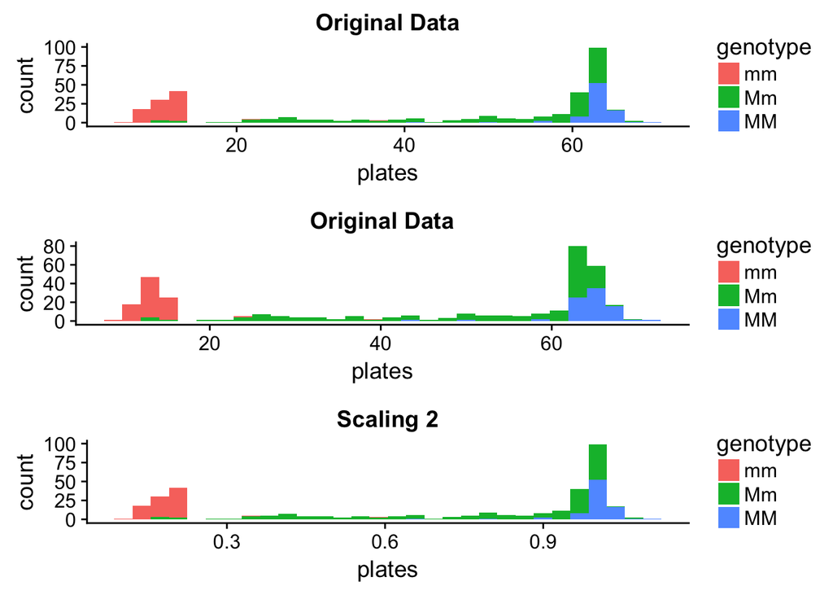

```r
# A histogram for the original data:
orig_hist <- ggplot(data = SticklebackPlates) +
              geom_histogram(aes(x = plates, fill = genotype), bins = 30) +
              ggtitle("Original Data")

# A histogram for the first scaling:
scale1_hist <- ggplot(data = SticklebackPlates_scale1) +
            geom_histogram(aes(x = plates, fill = genotype), bins = 30) +
            ggtitle("Original Data")


# A histogram for the second scaling:
scale2_hist <- ggplot(data = SticklebackPlates_scale2) +
            geom_histogram(aes(x = plates, fill = genotype), bins = 30) +
            ggtitle("Scaling 2")

# Let's put them together on a figure:
plot_grid(orig_hist, scale1_hist, scale2_hist, nrow = 3)
```

It seems that Scaling 1 changed the distribution - however, this is just an artefact of the plotting that can easily lead us astray. The data have changed, however, we’re plotting with the same intervals. Let’s see what happens if we finetune the binwidths a bit.

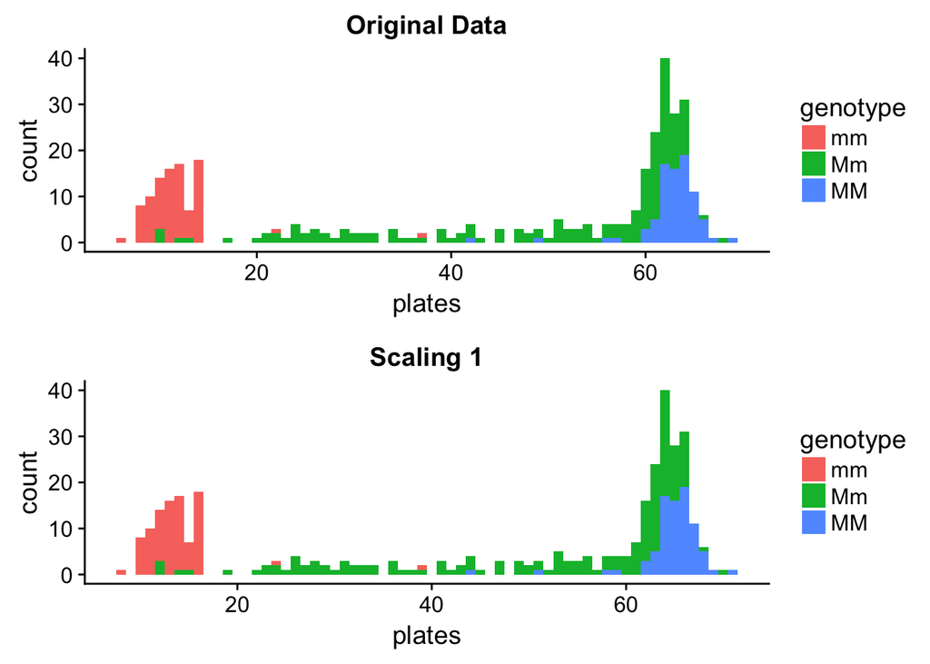

```r
# A histogram for the original data:
orig_hist <- ggplot(data = SticklebackPlates) +
              geom_histogram(aes(x = plates, fill = genotype), binwidth = 1) +
              ggtitle("Original Data")

# A histogram for the first scaling:
scale1_hist <- ggplot(data = SticklebackPlates_scale1) +
            geom_histogram(aes(x = plates, fill = genotype), binwidth = 1) +
            ggtitle("Scaling 1")

plot_grid(orig_hist, scale1_hist, nrow = 2)
```

We can see that the distributions are the same - the scaled one is just shifted to the right, and this was enough to make it show up as a different distribution when using a wider binwidth. This illustrates it very well that when you are creating histograms, you might need to try a couple different binwidths and choose the one that you think fits your data best.

Let’s see how the summary statistics have changed:

```r
# Means:
mean(SticklebackPlates$plates) # original data
```

```
## [1] 43.43314
```

```r
mean(SticklebackPlates_scale1$plates) # Scaling 1
```

```
## [1] 45.43314
```

```r
mean(SticklebackPlates$plates) + 2 # Equals the mean of the Scaling 1 data
```

```
## [1] 45.43314
```

```r
mean(SticklebackPlates_scale2$plates) # Scaling 2
```

```
## [1] 0.6916105
```

```r
mean(SticklebackPlates$plates)/62.8 # Equals the mean of the Scaling 2 data
```

```
## [1] 0.6916105
```

```r
# Standard deviations:
sd(SticklebackPlates$plates) # original data
```

```
## [1] 22.23716
```

```r
sd(SticklebackPlates_scale1$plates) # Scaling 1, same as the SD of the original data
```

```
## [1] 22.23716
```

```r
sd(SticklebackPlates_scale2$plates) # Scaling 2
```

```
## [1] 0.3540949
```

```r
sd(SticklebackPlates$plates)/62.8 # Equals the SD of the Scaling 2 data
```

```
## [1] 0.3540949
```

*Take me back to the beginning!*

### 3. Developing your intuition for histograms and boxplots

#### Reproduce figure 3-3-1 in the book using the histogram function hist().

This is how you do it in Base R:

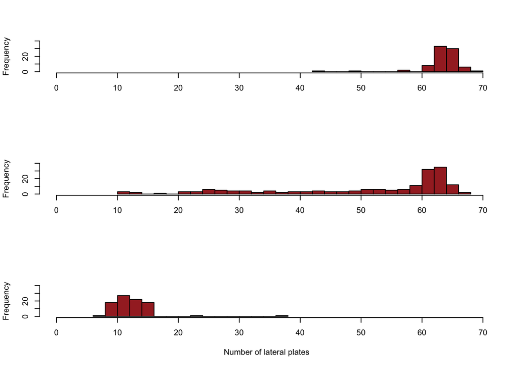

```r
par(mfrow=c(3,1))

hist(dataMM$plates,
     right = FALSE,
     breaks = 15,
     xlim = c(0,max(dataMM$plates)),
     ylim = c(0,40),
     col = "brown",
     main = "",
     xlab = "")

hist(dataMm$plates,
     right = FALSE,
     breaks = 30,
     xlim = c(0,max(dataMM$plates)),
     ylim = c(0,40),
     col = "brown",
     main = "",
     xlab = "")

hist(datamm$plates,
     right = FALSE,
     breaks = 15,
     xlim = c(0,max(dataMM$plates)),
     ylim = c(0,40),
     col = "brown",
     main = "",
     xlab = "Number of lateral plates")
```

This is how you do it in ggplot2 (okay, this is pretty complex but hey, at least it’s fancy, right?):

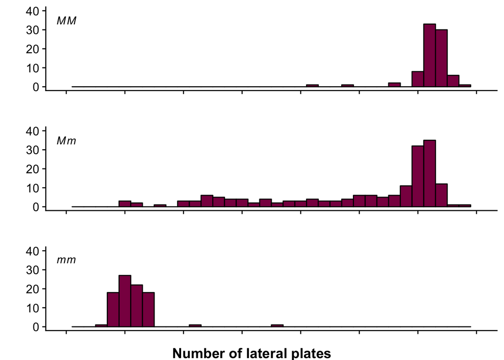

```r
plot_MM <- ggplot(data = dataMM) +
          geom_histogram(aes(x = plates), fill = "deeppink4", col = "black", binwidth = 2) +
          annotate("text", x = 0, y = 35, label = "italic(MM)", parse=TRUE) +
  scale_y_continuous(breaks=c(seq(0,40,10)), name = "", labels = seq(0,40,10), limits = c(0,40)) +
  scale_x_continuous(breaks=c(seq(0,70,10)), name = "", labels = NULL , limits = c(0,70))


plot_Mm <- ggplot(data = dataMm) +
          geom_histogram(aes(x = plates), fill = "deeppink4", col = "black", binwidth = 2) +
          annotate("text", x = 0, y = 35, label = "italic(Mm)", parse=TRUE) +
  scale_y_continuous(breaks=c(seq(0,40,10)), name = "", labels = seq(0,40,10), limits = c(0,40)) +
  scale_x_continuous(breaks=c(seq(0,70,10)), name = "", labels = NULL , limits = c(0,70))


plot_mm <- ggplot(data = datamm) +
          geom_histogram(aes(x = plates), fill = "deeppink4", col = "black", binwidth = 2) +
          annotate("text", x = 0, y = 35, label = "italic(mm)", parse=TRUE) +
  scale_y_continuous(breaks=c(seq(0,40,10)), name = "", labels = seq(0,40,10), limits = c(0,40)) +
  scale_x_continuous(breaks=c(seq(0,70,10)), name = "", labels = NULL , limits = c(0,70))


plot_grid(plot_MM, plot_Mm, plot_mm, nrow =  3) +
  draw_label("Number of lateral plates", fontface = "bold", y = 0.02)
```

#### Complement the figure by doing a side by side boxplot for each genotype (hint: use boxplot() ).

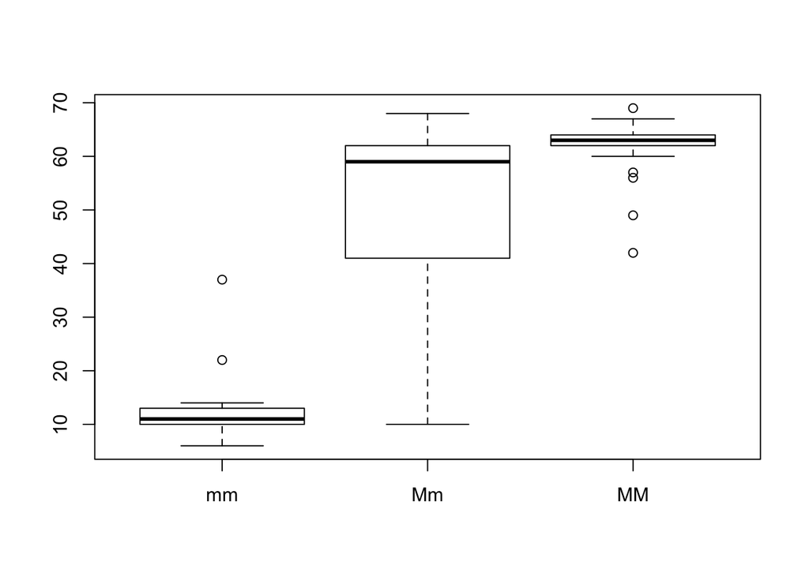

```r
boxplot(SticklebackPlates$plates ~ SticklebackPlates$genotype)
```

```r
# first you say what the numerical variable should be that you want to plot (here: plates)
# then you say what categories your data has, which will create the different boxplots (here: genotype)
```

#### Sketch by hand and do in R a graph of the cumulative distribution of the number of lateral plates in the Sticklebacks data. (hint: Google it!)

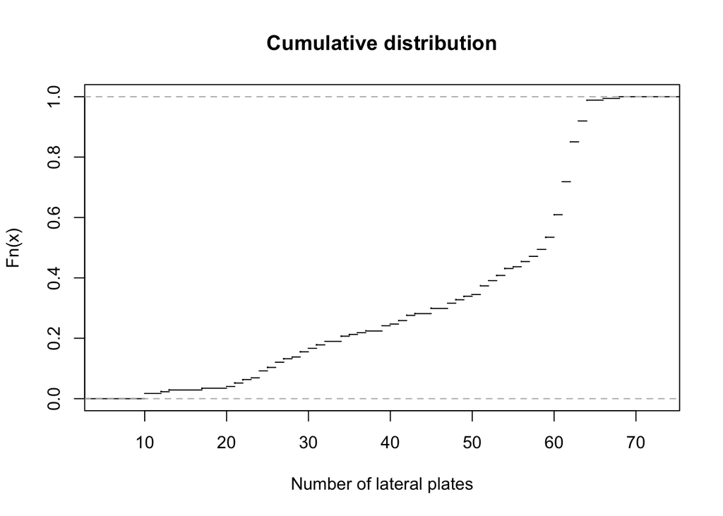

```r
plot(ecdf(dataMm$plates), main = "Cumulative distribution", xlab = "Number of lateral plates", pch = ".")
```

```r
# ecdf: Empirical Cumulative Distribution Function - we want to plot it
# pch stands for plotting character - it's responsible for how your plotted points look
```

*Take me back to the beginning!*

### 4. Making up your own data by sampling from a theoretical distribution

In R, you can very easily “draw” observations from the normal distribution (pictured in Fig 1-4.2, described in Chapter 10).

```r
meanOfMM=62.8 #the observed mean of MM individuals
SDOfMM=3.4 # standard deviation of the MM individuals
myFakeSample=rnorm(n = 82, mean = meanOfMM, sd=SDOfMM) ## 82 independent observations drawn from the normal distribution that matches the data (aka has the same mean and standard deviation as the original data)
myFakeSample
```

```
##  [1] 61.03078 63.41249 63.59052 64.90358 65.71962 60.07470 63.11198
##  [8] 59.17085 64.69749 60.36808 67.79215 64.28422 60.62038 64.50728
## [15] 61.08972 63.12226 60.53933 59.15287 62.99824 65.11743 60.98840
## [22] 62.44364 69.37996 65.37276 56.81266 59.72702 70.10720 58.41700
## [29] 61.15207 66.60990 63.48996 61.05480 60.34951 63.54790 62.40870
## [36] 64.92435 62.05033 62.77471 60.02690 64.52047 58.58936 66.24430
## [43] 63.41587 61.38706 65.69601 66.70394 62.25593 68.82592 57.46552
## [50] 59.42510 65.08211 61.23289 62.07894 57.34699 63.81236 68.67148
## [57] 66.76126 60.72546 57.50661 60.86287 67.55945 52.98923 71.19157
## [64] 63.54061 64.87219 67.82068 72.50079 67.59651 60.84744 66.50885
## [71] 54.71989 67.97124 70.48017 62.31530 69.64135 65.78939 62.16041
## [78] 65.25434 59.91638 67.77262 62.40442 66.68099
```

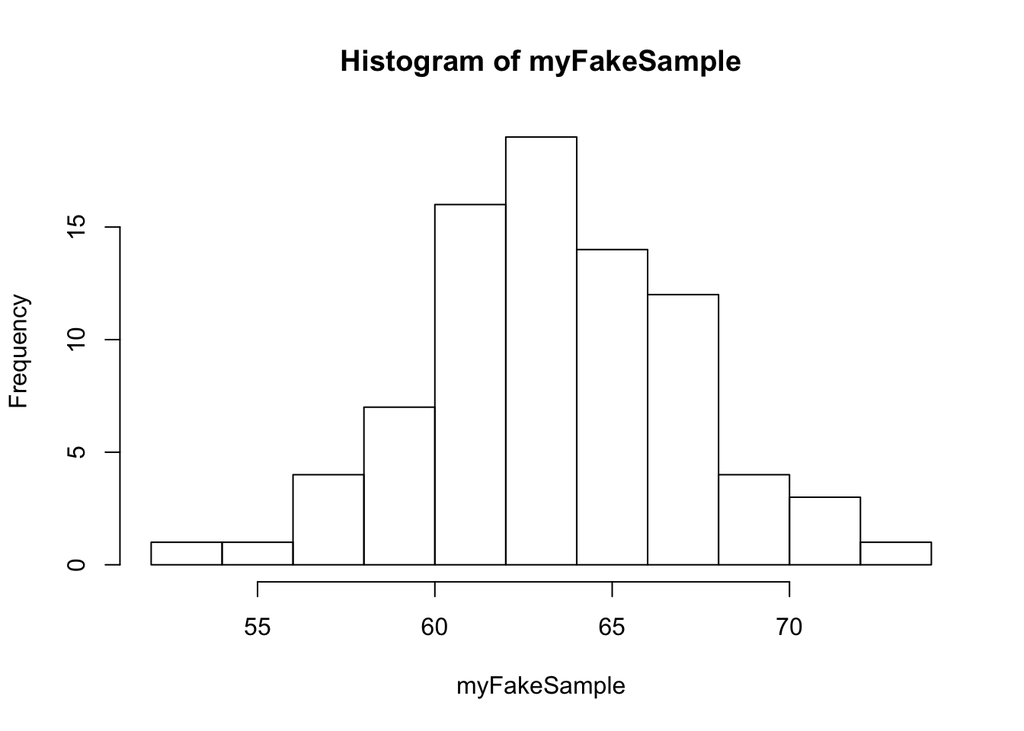

```r
hist(myFakeSample)
```

**rnorm:** draws values from the normal distribution, **n** is the number of samples drawn, **mean** and **sd** is the mean and standard distribution of the normal distribution we’re drawing from.

#### Discuss to what extent is this fake sample a good “match” to the actual data.

It’s a good idea to generate fake samples for every genotype, then plot them to see how well the distributions match.

```r
# drawing samples
fakeMM=rnorm(n = length(dataMM$plates), mean = mean(dataMM$plates), sd=sd(dataMM$plates))
# putting them in a dataframe for plotting purposes
fakeMM_df <- data_frame(genotype = rep("MM", length(fakeMM)),
                        plates = fakeMM)

fakeMm=rnorm(n = length(dataMm$plates), mean = mean(dataMm$plates), sd=sd(dataMm$plates))

fakeMm_df <- data_frame(genotype = rep("Mm", length(fakeMm)),
                        plates = fakeMm)

fakemm=rnorm(n = length(datamm$plates), mean = mean(datamm$plates), sd=sd(datamm$plates))

fakemm_df <- data_frame(genotype = rep("mm", length(fakemm)),
                        plates = fakemm)
```

Let’s do it in Base R first:

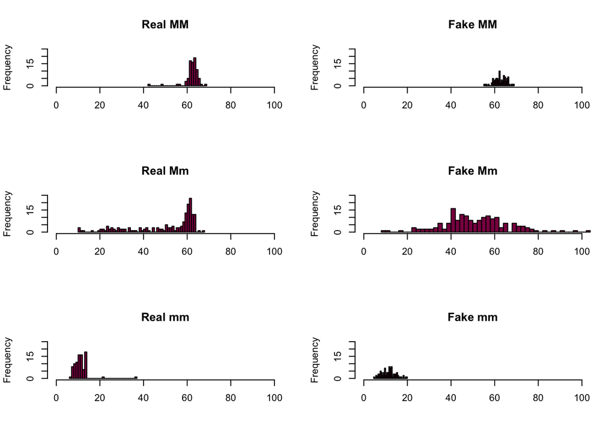

```r
par(mfrow = c(3, 2))

plot1b <- hist(dataMM$plates,
               breaks = 30,
               col = "deeppink4",
               xlim = c(0, 100),
               ylim = c(0, 25),
               xlab = "",
               main = "Real MM")

plot2b <- hist(fakeMM_df$plates,
               breaks = 30,
               col = "deeppink4",
               xlim = c(0, 100),
               ylim = c(0, 25),
               xlab = "",
               main = "Fake MM")

plot3b <- hist(dataMm$plates,
               breaks = 50,
               col = "deeppink4",
               xlim = c(0, 100),
               ylim = c(0, 25),
               xlab = "",
               main = "Real Mm")

plot4b <- hist(fakeMm_df$plates,
               breaks = 50,
               col = "deeppink4",
               xlim = c(0, 100),
               ylim = c(0, 25),
               xlab = "",
               main = "Fake Mm")

plot5b <- hist(datamm$plates,
               breaks = 30,
               col = "deeppink4",
               xlim = c(0, 100),
               ylim = c(0, 25),
               xlab = "",
               main = "Real mm")

plot6b <- hist(fakemm_df$plates,
               breaks = 30,
               col = "deeppink4",
               xlim = c(0, 100),
               ylim = c(0, 25),
               xlab = "",
               main = "Fake mm")
```

Here is the ggplot version:

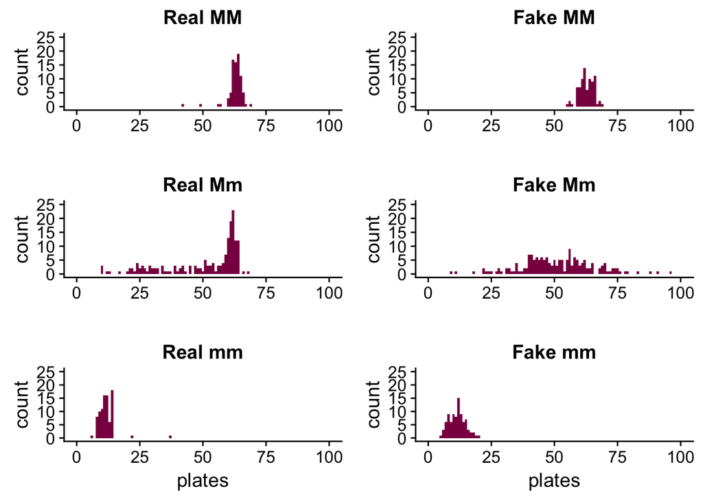

```r
plot1 <- ggplot(data = dataMM) +
  geom_histogram(aes(x = plates), binwidth = 1, fill = "deeppink4") +
  ggtitle("Real MM") +
  xlim(c(0,100)) +
  ylim(c(0,25)) +
  xlab("")

plot2 <- ggplot(data = fakeMM_df) +
  geom_histogram(aes(x = plates), binwidth = 1, fill = "deeppink4") +
  ggtitle("Fake MM") +
  xlim(c(0,100)) +
  ylim(c(0,25)) +
  xlab("")

plot3 <- ggplot(data = dataMm) +
  geom_histogram(aes(x = plates), binwidth = 1, fill = "deeppink4") +
  ggtitle("Real Mm") +
  xlim(c(0,100)) +
  ylim(c(0,25)) +
  xlab("")

plot4 <- ggplot(data = fakeMm_df) +
  geom_histogram(aes(x = plates), binwidth = 1, fill = "deeppink4") +
  ggtitle("Fake Mm") +
  xlim(c(0,100)) +
  ylim(c(0,25)) +
  xlab("")

plot5 <- ggplot(data = datamm) +
  geom_histogram(aes(x = plates), binwidth = 1, fill = "deeppink4") +
  ggtitle("Real mm") +
  xlim(c(0,100)) +
  ylim(c(0,25))

plot6 <- ggplot(data = fakemm_df) +
  geom_histogram(aes(x = plates), binwidth = 1, fill = "deeppink4") +
  ggtitle("Fake mm") +
  xlim(c(0,100)) +
  ylim(c(0,25))

plot_grid(plot1, plot2, plot3, plot4, plot5, plot6, ncol = 2)
```

We can see that in the case of the MM and mm genotypes the fake data is a pretty good match - the reason for this is because these distributions were approximately normal to begin with, so it’s easier to simulate them by drawing observations from a normal distribution.

This is not the case with the Mm genotype - the fake sample is all over the place. It’s because the real distribution isn’t close to a normal distribution, so if we want to simulate it by drawing samples from a normal distribution, we won’t succeed. We just get something that has a similar standard deviation and mean as the original distribution (because remember, we sampled using these values), but the shape isn’t maintained.

#### For each genotype, use summaries of the simulated data (mean, median, variance, quantiles, min, max) and discuss whether the simulated data (assuming the normal) are looking like the real one.

```r
summary(dataMM)
```

```
##  genotype     plates
##  mm: 0    Min.   :42.00
##  Mm: 0    1st Qu.:62.00
##  MM:82    Median :63.00
##           Mean   :62.78
##           3rd Qu.:64.00
##           Max.   :69.00
```

```r
summary(fakeMM_df)
```

```
##    genotype             plates
##  Length:82          Min.   :55.21
##  Class :character   1st Qu.:60.80
##  Mode  :character   Median :62.43
##                     Mean   :62.69
##                     3rd Qu.:64.71
##                     Max.   :68.85
```

```r
summary(dataMm)
```

```
##  genotype     plates
##  mm:  0   Min.   :10.00
##  Mm:174   1st Qu.:41.00
##  MM:  0   Median :59.00
##           Mean   :50.38
##           3rd Qu.:62.00
##           Max.   :68.00
```

```r
summary(fakeMm_df)
```

```
##    genotype             plates
##  Length:174         Min.   :  9.342
##  Class :character   1st Qu.: 41.598
##  Mode  :character   Median : 50.297
##                     Mean   : 51.343
##                     3rd Qu.: 60.007
##                     Max.   :102.386
```

```r
summary(datamm)
```

```
##  genotype     plates
##  mm:88    Min.   : 6.00
##  Mm: 0    1st Qu.:10.00
##  MM: 0    Median :11.00
##           Mean   :11.67
##           3rd Qu.:13.00
##           Max.   :37.00
```

```r
summary(fakemm_df)
```

```
##    genotype             plates
##  Length:88          Min.   : 4.821
##  Class :character   1st Qu.: 9.023
##  Mode  :character   Median :11.651
##                     Mean   :11.450
##                     3rd Qu.:13.541
##                     Max.   :19.629
```

#### Is the simulated data able to reproduce sample the property of the sample:

- the mean and median ?

```r
mean(dataMM$plates)
```

```
## [1] 62.78049
```

```r
mean(fakeMM_df$plates)
```

```
## [1] 62.69023
```

```r
mean(dataMm$plates)
```

```
## [1] 50.37931
```

```r
mean(fakeMm_df$plates)
```

```
## [1] 51.34316
```

```r
mean(datamm$plates)
```

```
## [1] 11.67045
```

```r
mean(fakemm_df$plates)
```

```
## [1] 11.45023
```

The means match up nicely, but it’s no surprise since we specified the means when we were generating the fake samples.

```r
median(dataMM$plates)
```

```
## [1] 63
```

```r
median(fakeMM_df$plates)
```

```
## [1] 62.42511
```

```r
median(dataMm$plates)
```

```
## [1] 59
```

```r
median(fakeMm_df$plates)
```

```
## [1] 50.29674
```

```r
median(datamm$plates)
```

```
## [1] 11
```

```r
median(fakemm_df$plates)
```

```
## [1] 11.65073
```

The medians match for the MM and mm genotypes and differ quite a bit for the Mm genotype - this just supports what we have seen on the plots before. In the real data the median is more to the right (we have a skewed distribution there), most likely somewhere around the peak, while in the fake data it’s close to the mean and around the middle of the distribution (which is expected because in the normal distribution the mean and the median are identical, while in the real Mm data this is not the case).

- the SD ?

```r
sd(dataMM$plates)
```

```
## [1] 3.410313
```

```r
sd(fakeMM_df$plates)
```

```
## [1] 2.830134
```

```r
sd(dataMm$plates)
```

```
## [1] 15.14687
```

```r
sd(fakeMm_df$plates)
```

```
## [1] 15.07384
```

```r
sd(datamm$plates)
```

```
## [1] 3.567805
```

```r
sd(fakemm_df$plates)
```

```
## [1] 3.253949
```

The standard deviations match up as well because we also specified them when generating the fake samples.

- some other aspect of the data such as the more outlier points (such as the lowest value)?

```r
min(dataMM$plates)
```

```
## [1] 42
```

```r
min(fakeMM_df$plates)
```

```
## [1] 55.20833
```

```r
min(dataMm$plates)
```

```
## [1] 10
```

```r
min(fakeMm_df$plates)
```

```
## [1] 9.342359
```

```r
min(datamm$plates)
```

```
## [1] 6
```

```r
min(fakemm_df$plates)
```

```
## [1] 4.820629
```

```r
max(dataMM$plates)
```

```
## [1] 69
```

```r
max(fakeMM_df$plates)
```

```
## [1] 68.84529
```

```r
max(dataMm$plates)
```

```
## [1] 68
```

```r
max(fakeMm_df$plates)
```

```
## [1] 102.3858
```

```r
max(datamm$plates)
```

```
## [1] 37
```

```r
max(fakemm_df$plates)
```

```
## [1] 19.62862
```

If we look at the two extremes, we see that they don’t match up perfectly - but we can see these on the plots as well. This is most likely due to the random sampling process - we can’t quite expect to be as lucky as to pick the same minimum and maximum values at random as we have in the original data, especially when we are working with a relatively low sample size.

*Take me back to the beginning!*

This R notebook was made by Judit Kisistók, incorporating some snippets from Moisés Coll Maciá’s solution sheet.  
The R exercise session was created by Palle Villesen and Thomas Bataillon at Aarhus University.